# Статистический анализ данных (Задание 4)

Мурат Апишев, группа №417

Среда, 9 апреля, 2015

#### Постановка

В данном задании предлагается произвести сравнение моделей для прогнозирования временных рядов и использовать лучшую для решения задачи предсказания. Использоваться будут модели ETC и ARIMA.

#### Данные

Исходные данные представляют собой информацию о ежемесячном числе проданных автомобилей в городе Квебек в период с января 1960 по декабрь 1968. Указанный временной ряд содержит $12 * 9 = 108$ отсчётов. Визуальный вид данных:

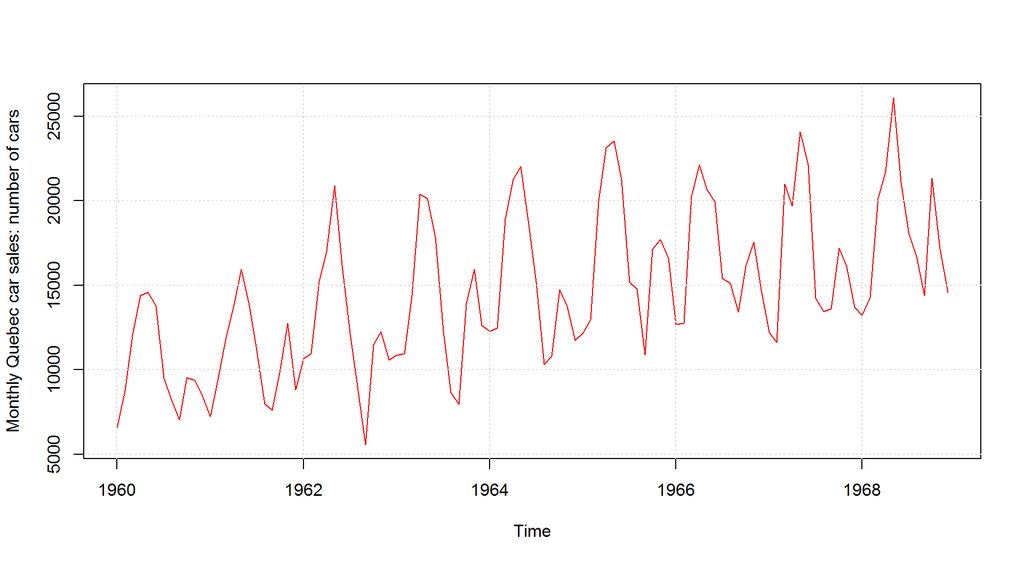

Из графика можно сделать следующие выводы:

- Выражена сезонность с периодом в $1$ год.
- Пик продаж приходится примерно на середину года, минимумы — на начало года и конец лета.
- Выражен линейный возрастающий тренд.
- Существенных выбросов не наблюдается.

#### Преобразования ряда

Попробуем поделить на число дней в месяце:

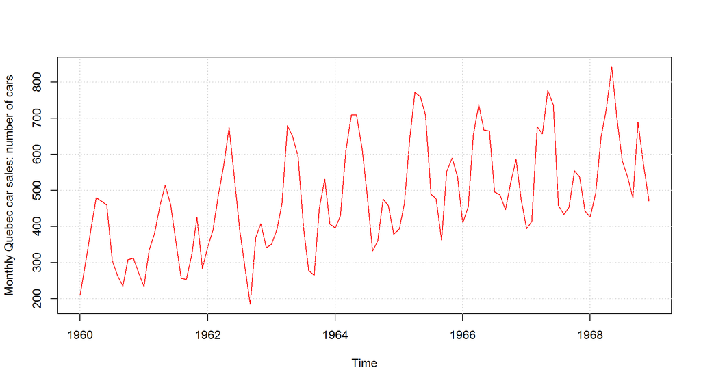

Ряд не стал более регулярным, так что вернёмся к исходным данным.

Проверим необходимость применения преобразования Бокса-Кокса. Применим критерий гомоскедастичности Бройша-Пагана для исследования зависимости дисперсии от времени:

```
##
##  studentized Breusch-Pagan test
##
## data:  Value ~ Date
## BP = 0.9954, df = 1, p-value = 0.3184
```

Видно, что дисперсия не зависит от времени, т.е. преобразование Бокса-Кокса можно не производить.

Приняв допустимым уровнем значимости $0.05$, проведём исследование стационарности ряда с помощью критерия KPSS:

```
##
##  KPSS Test for Level Stationarity
##
## data:  tSeries
## KPSS Level = 1.6054, Truncation lag parameter = 2, p-value = 0.01
```

Гипотеза о стационарности рассматриваемого ряда отвергается. Попробуем провести сезонное дифференцирование и проверить стационарность получаемого ряда:

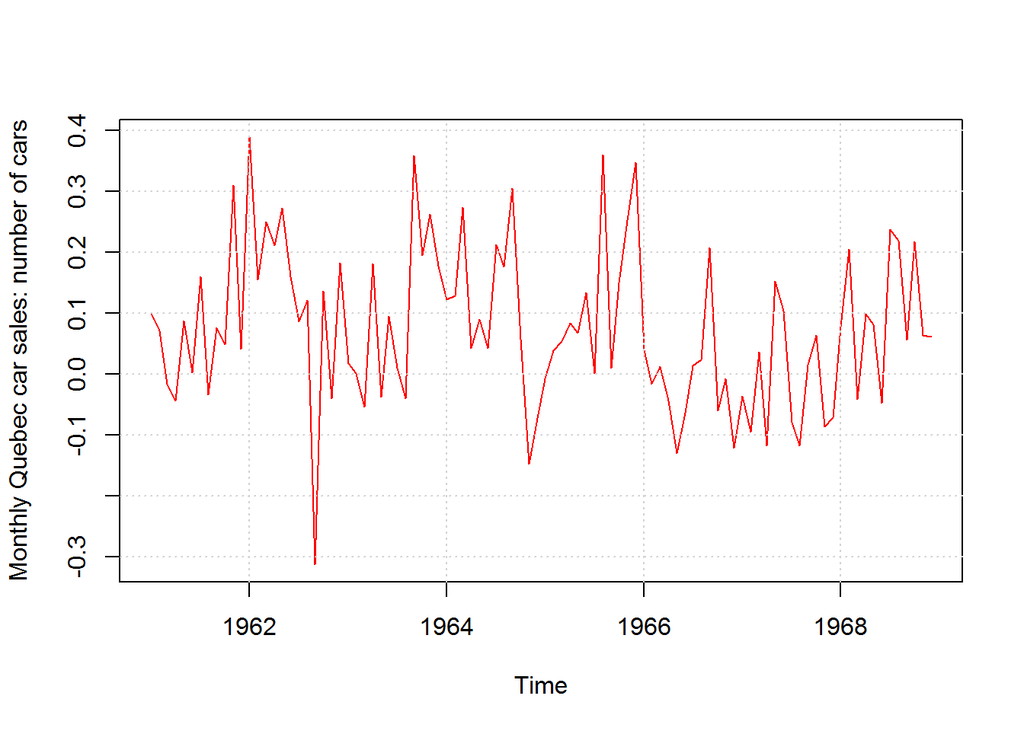

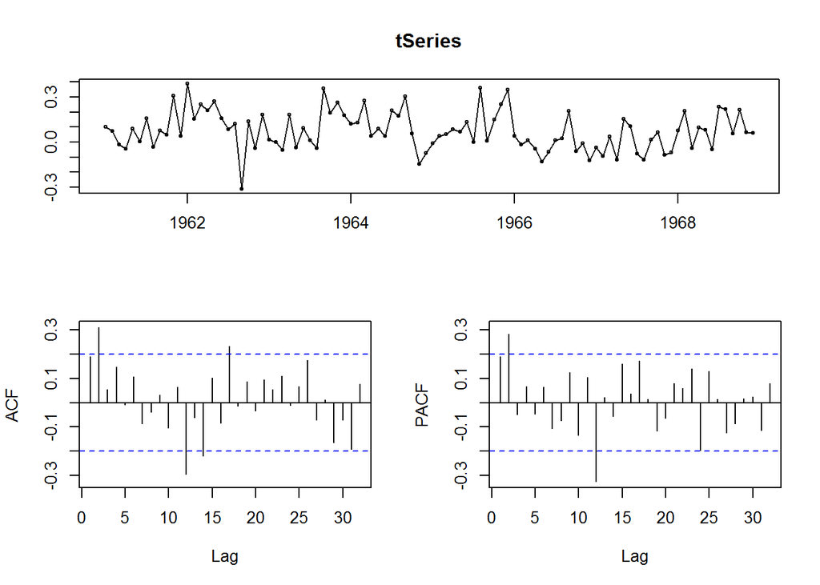

```
##
##  KPSS Test for Level Stationarity
##
## data:  tSeries
## KPSS Level = 0.3208, Truncation lag parameter = 2, p-value = 0.1
```

#### ETS

Обучим модель экспоненциального сглаживания на исходном ряде:

```
## ETS(A,A,A)
##
## Call:
##  ets(y = tSeriesOld)
##
##   Smoothing parameters:
##     alpha = 0.1545
##     beta  = 1e-04
##     gamma = 1e-04
##
##   Initial states:
##     l = 9882.811
##     b = 74.0096
##     s=-2423.577 -53.031 -434.8474 -4695.859 -3298.765 -1042.722
##            3740.085 6633.78 4953.69 2883.802 -2819.791 -3442.765
##
##   sigma:  1341.674
##
##      AIC     AICc      BIC
## 2093.232 2099.210 2136.146
```

Остатки:

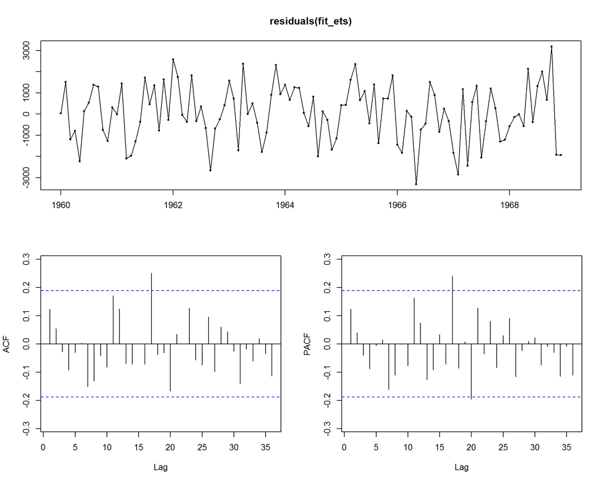

Достигаемые уровни значимости критерия Льюнга-Бокса для них:

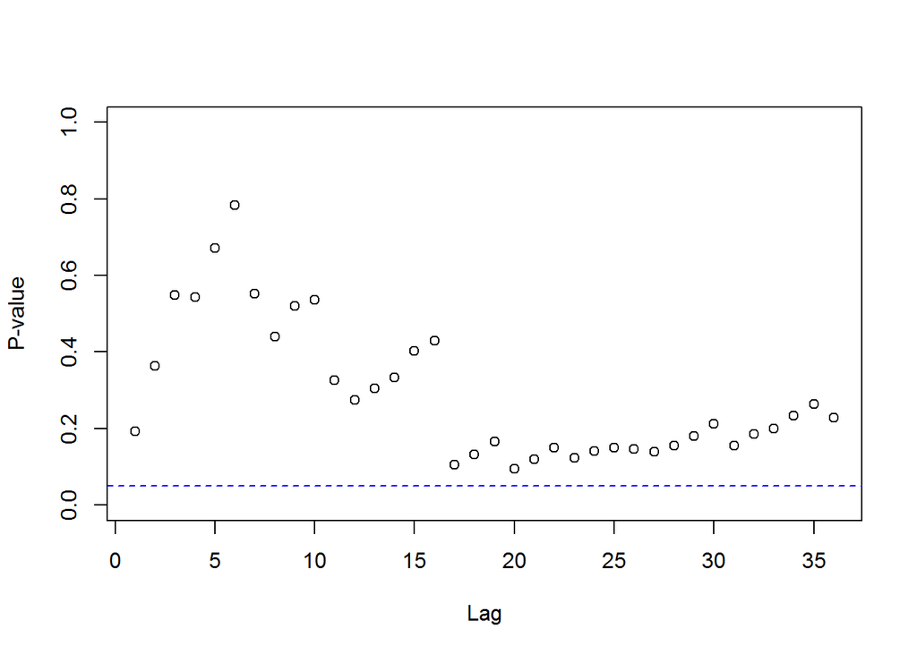

Q-Q plot и гистограмма для остатков:

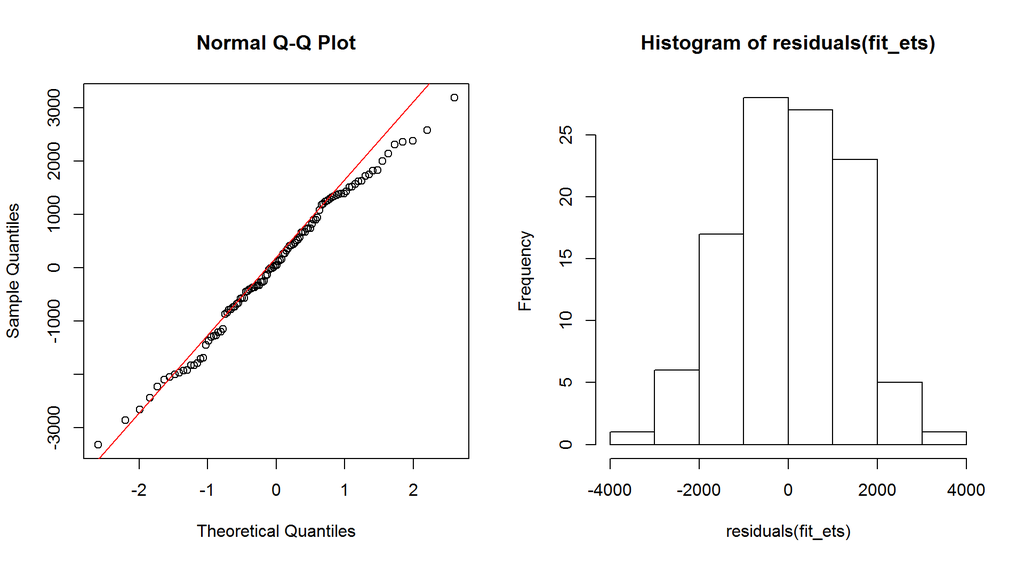

| Гипотеза | Критерий | Результат проверки | Достигаемый уровень значимости |
| --- | --- | --- | --- |
| Нормальность | Шапиро-Уилка | не отвергается | 0.5810891 |
| Несмещённость | Уилкоксона | не отвергается | 0.6489843 |
| Стационарность | KPSS | не отвергается | 0.1 |
| Гомоскедастичность | Бройша-Пагана | не отвергается | 0.2234945 |

#### Arima

Будем определять модель ARIMA исходя из визуального анализа ряда и вида его автокорреляционной функции.

- PASF велико для лагов 1 и 2 — добавим компоненту AR(2).
- PASF отрицательна для лага 12 — добавим компоненту SMA(1).

Итак, строим модель ARIMA(2,0,0)(0,1,1)$_{12}$:

```
## Series: tSeriesOld
## ARIMA(2,0,0)(0,1,1)[12]
##
## Coefficients:
##          ar1     ar2     sma1
##       0.3854  0.3726  -0.4148
## s.e.  0.1051  0.0954   0.1439
##
## sigma^2 estimated as 2658385:  log likelihood=-847.76
## AIC=1703.53   AICc=1703.97   BIC=1713.79
```

Остатки:

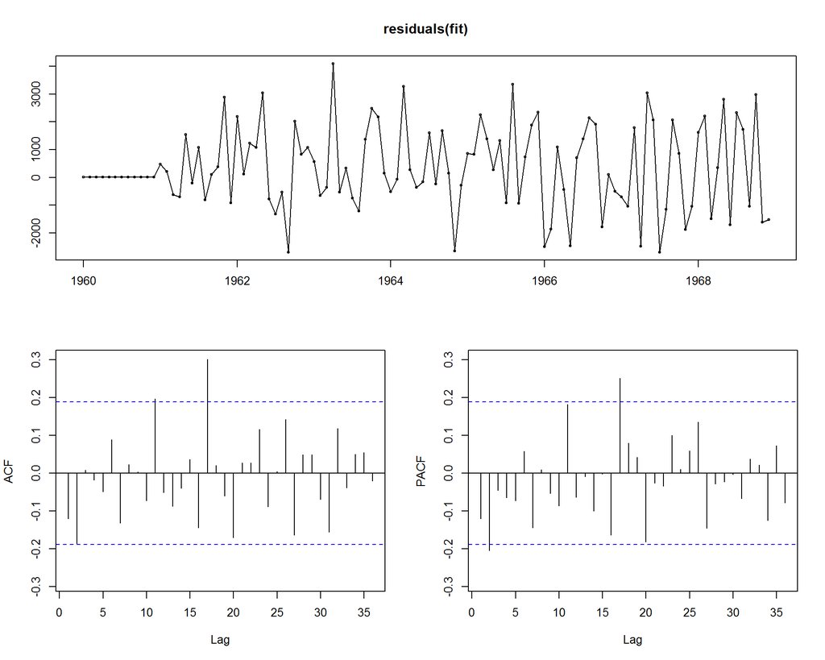

Достигаемые уровни значимости критерия Льюнга-Бокса для них:

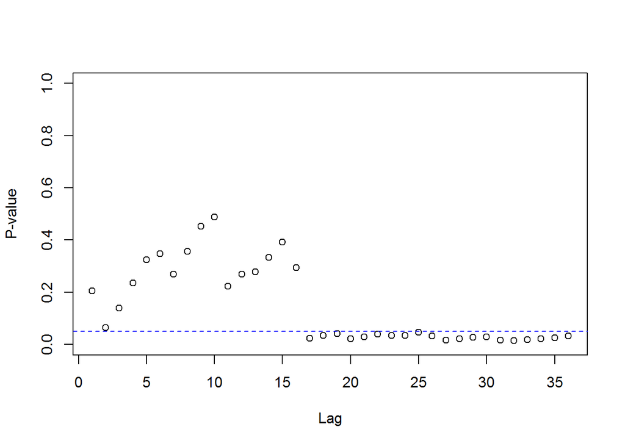

Q-Q plot и гистограмма для остатков:

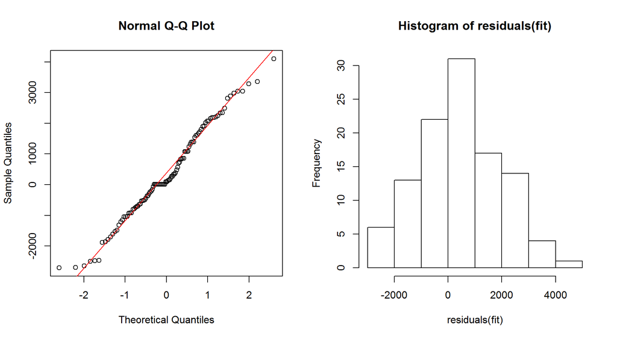

Сравним теперь полученную модель с близкими ей по значению AIC$_c$ и выберем лучшую:

| Модель | AIC$_c$ |
| --- | --- |
| ARIMA(2,0,0)(0,1,1)$_{12}$ | $1703$ |
| ARIMA(1,0,0)(0,1,1)$_{12}$ | $1715$ |
| ARIMA(3,0,0)(0,1,1)$_{12}$ | $1702$ |
| ARIMA(2,0,1)(0,1,1)$_{12}$ | $1696$ |
| ARIMA(2,0,2)(0,1,1)$_{12}$ | $1697$ |
| ARIMA(2,0,0)(0,0,1)$_{12}$ | $1994$ |
| ARIMA(2,0,1)(0,0,1)$_{12}$ | $1997$ |
| ARIMA(2,0,0)(1,1,0)$_{12}$ | $1705$ |
| ARIMA(2,0,0)(1,1,1)$_{12}$ | $1705$ |

Моделей,существенно лучших ARIMA(2,0,0)(0,1,1)$_{12}$, не оказалось.Попробуем теперь построить модель автоматически и сравним результат с построенной выше вручную моделью:

```
## Series: tSeriesOld
## ARIMA(1,0,1)(0,1,1)[12] with drift
##
## Coefficients:
##          ar1      ma1     sma1    drift
##       0.7663  -0.5394  -0.5619  83.3957
## s.e.  0.1801   0.2360   0.1429  13.7596
##
## sigma^2 estimated as 2550339:  log likelihood=-735.2
## AIC=1480.4   AICc=1481.06   BIC=1493.22
```

Построенная автоматически модель оказалась лучше по AIC$_c$.

Проанализируем её остатки

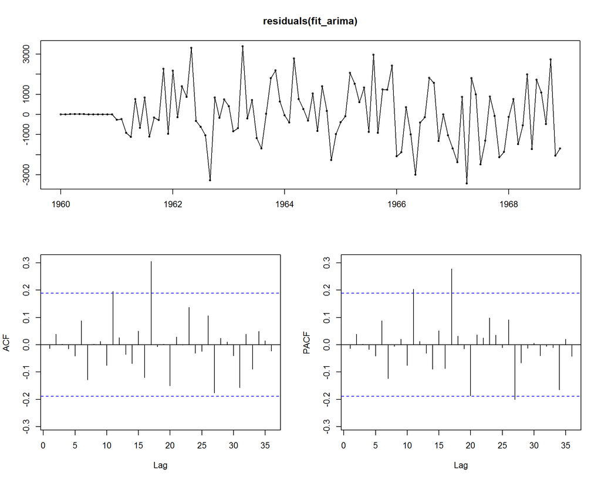

Достигаемые уровни значимости критерия Льюнга-Бокса для них:

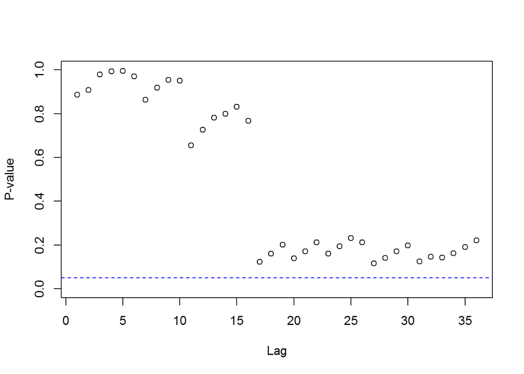

Q-Q plot и гистограмма для остатков:

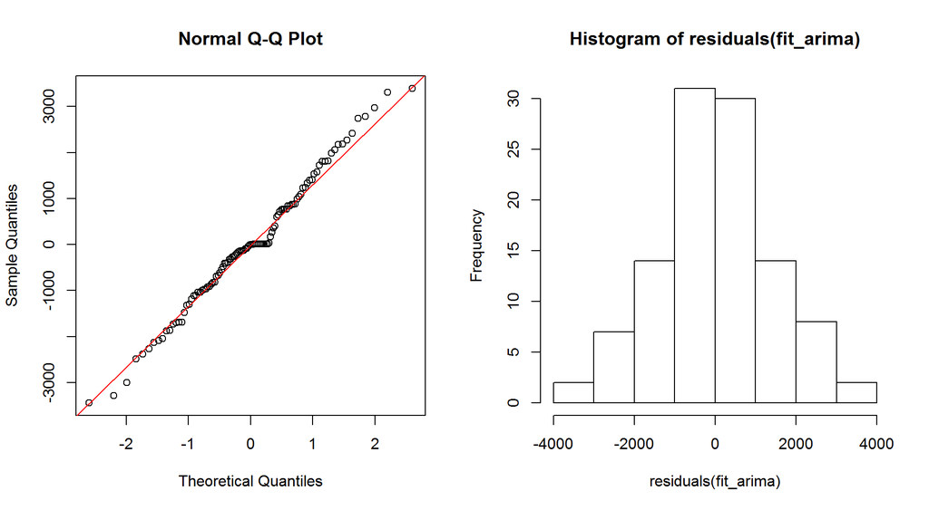

Распределение имеет лёгкие хвосты. Несмотря на наличие значимых лагов, p-values для критерия Льюнга-Бокса превосходят допустимый уровень значимости. Остатки удовлетворяют некоторым основным необходимым свойствам:

| Гипотеза | Критерий | Результат проверки | Достигаемый уровень значимости |
| --- | --- | --- | --- |
| Нормальность | Шапиро-Уилка | не отвергается | 0.5438161 |
| Несмещённость | Уилкоксона | не отвергается | 0.9182152 |
| Стационарность | KPSS | не отвергается | 0.1 |
| Гомоскедастичность | Бройша-Пагана | отвергается | 0.0078911 |

#### Сравнение моделей

Сравним между собой модели, полученные с помощью ETS и ARIMA, с помощью критерия Диболда-Мариано. Альтернативная гипотеза — вторая модель хуже первой. В качестве тестовой выборки возьмём значения продаж за последние полтора года (18 отсчётов), всё остальное используем для обучения:

```
##
##  Diebold-Mariano Test
##
## data:  residuals(fit_ets)residuals(fit_arima)
## DM = -0.905, Forecast horizon = 1, Loss function power = 2,
## p-value = 0.1837
## alternative hypothesis: less
```

```
##
##  Diebold-Mariano Test
##
## data:  residuals(fit_arima)residuals(fit_ets)
## DM = 0.905, Forecast horizon = 1, Loss function power = 2, p-value
## = 0.8163
## alternative hypothesis: less
```

p-value также высокое, значит, критерий Диболда-Мариано не может различить две модели. В таком случае возьмём ту, для которой меньше значение AIC$_c$, а это ARIMA (1481 против 2100).

Используем итоговую модель ARIMA, обученную на всём исходном временном ряде для прогнозирования продаж на ближайшие два года:

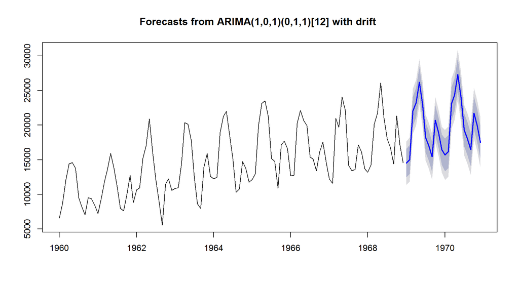